# Guana River Marsh Aquatic Preserve

SEACAR Water Quality Analysis

Last compiled on 15 July, 2026

# Indicators

## Nutrients

### Total Nitrogen - Discrete

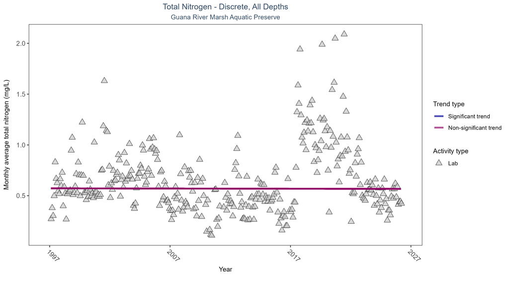

Scatter plot of monthly average total nitrogen over time. If the time series included ten or more years of discrete observations, a significant (blue) or non-significant (magenta) trend line is also shown. Only nitrogen values obtained from laboratory analyses (triangles) are included in the plot.

Table:

Total nitrogen showed no detectable trend between 1997 and 2026.

| Activity Type | Statistical Trend | Sample Count | Years with Data | Period of Record | Median Result Value | Tau | Sen Intercept | Sen Slope | P |
| --- | --- | --- | --- | --- | --- | --- | --- | --- | --- |
| Lab | No detectable trend | 2066 | 30 | 1997 - 2026 | 0.607 | -0.00394 | 0.57257 | -0.00018 | 0.9248 |

[figure not shown]

Map showing location of discrete water quality sampling locations within the boundaries of *Guana River Marsh Aquatic Preserve*. The bubble size on the maps above reflect the amount of data available at each sampling site.

### Total Phosphorus - Discrete

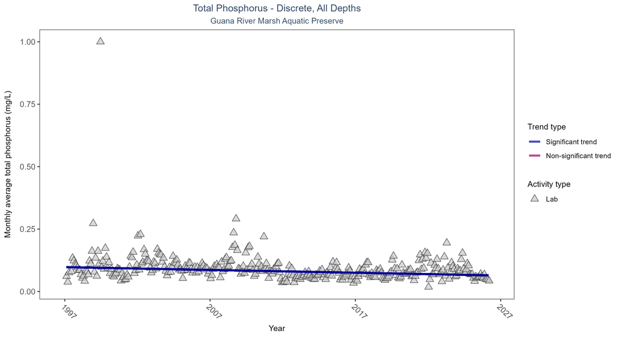

Scatter plot of monthly average total phosphorus over time. If the time series included ten or more years of discrete observations, a significant (blue) or non-significant (magenta) trend line is also shown. Only phosphorus values obtained from laboratory analyses (triangles) are included in the plot.

Table:

Monthly average total phosphorus decreased by less than 0.01 mg/L per year.

| Activity Type | Statistical Trend | Sample Count | Years with Data | Period of Record | Median Result Value | Tau | Sen Intercept | Sen Slope | P |
| --- | --- | --- | --- | --- | --- | --- | --- | --- | --- |
| Lab | Decreasing trend | 2996 | 30 | 1997 - 2026 | 0.075 | -0.23835 | 0.09759 | -0.00112 | 0 |

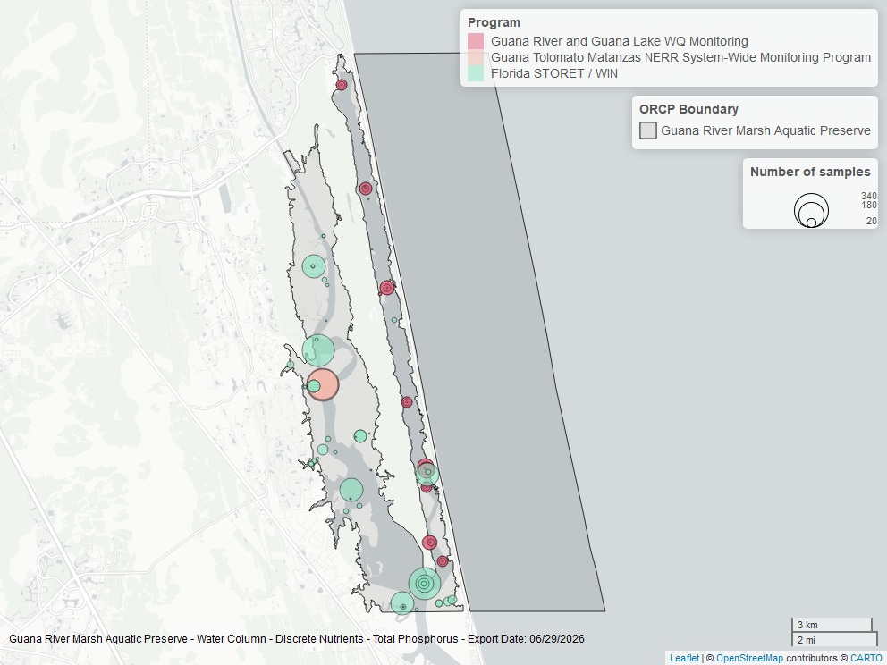

Map showing location of discrete water quality sampling locations within the boundaries of *Guana River Marsh Aquatic Preserve*. The bubble size on the maps above reflect the amount of data available at each sampling site.

## Water Quality

### Dissolved Oxygen - Continuous

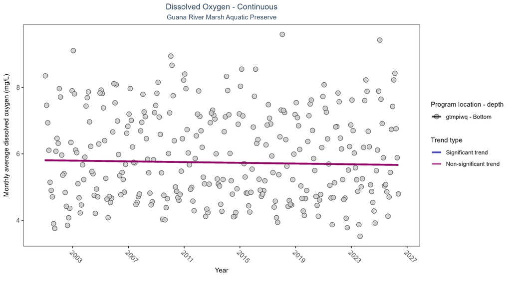

Scatter plot of monthly average dissolved oxygen over time at continuously monitored program locations. Each location is analyzed separately, with significant (blue) or non-significant (magenta) trend lines shown for time series that included five or more years of observations.

Table:

No detectable change in monthly average dissolved oxygen was observed at one location.

| Program Location | Statistical Trend | Sample Count | Years with Data | Period of Record | Median Result Value | Tau | Sen Intercept | Sen Slope | P |
| --- | --- | --- | --- | --- | --- | --- | --- | --- | --- |
| gtmpiwq | No detectable trend | 708889 | 26 | 2001 - 2026 | 5.9 | -0.08 | 5.81 | -0.01 | 0.07 |

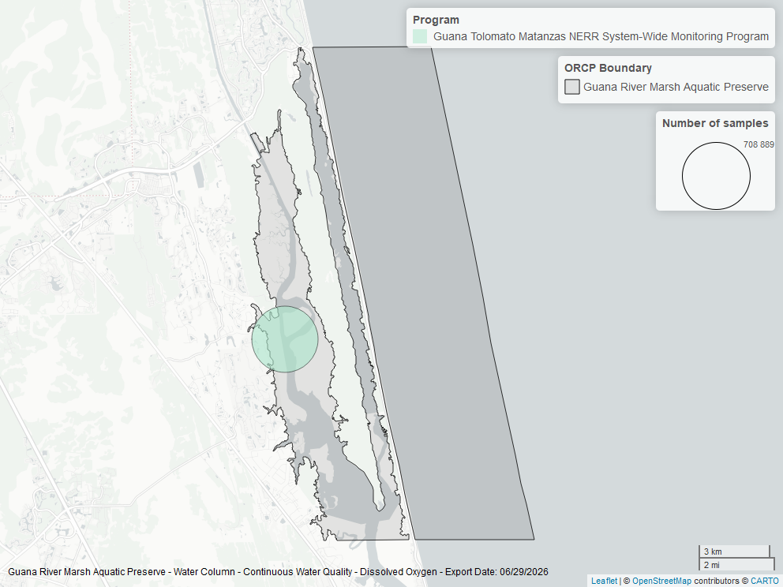

Map showing location of dissolved oxygen continuous water quality sampling locations within the boundaries of *Guana River Marsh Aquatic Preserve*. The bubble size on the maps above reflect the amount of data available at each sampling site.

### Dissolved Oxygen - Discrete

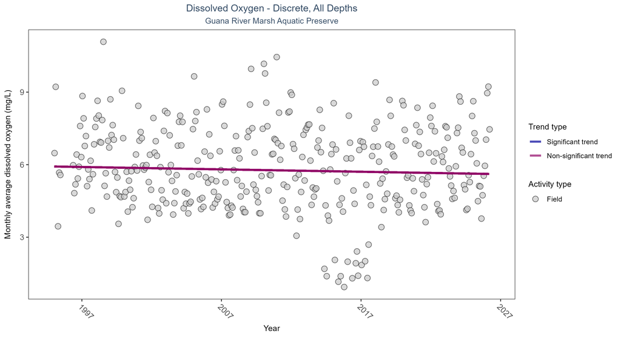

Scatter plot of monthly average dissolved oxygen over time. If the time series included ten or more years of discrete observations, a significant (blue) or non-significant (magenta) trend line is also shown. Only dissolved oxygen values measured in the field (circles) are included in the plot.

Table:

Dissolved oxygen showed no detectable trend between 1995 and 2026.

| Activity Type | Statistical Trend | Sample Count | Years with Data | Period of Record | Median Result Value | Tau | Sen Intercept | Sen Slope | P |
| --- | --- | --- | --- | --- | --- | --- | --- | --- | --- |
| Field | No detectable trend | 7710 | 32 | 1995 - 2026 | 5.7 | -0.06498 | 5.92403 | -0.00985 | 0.082 |

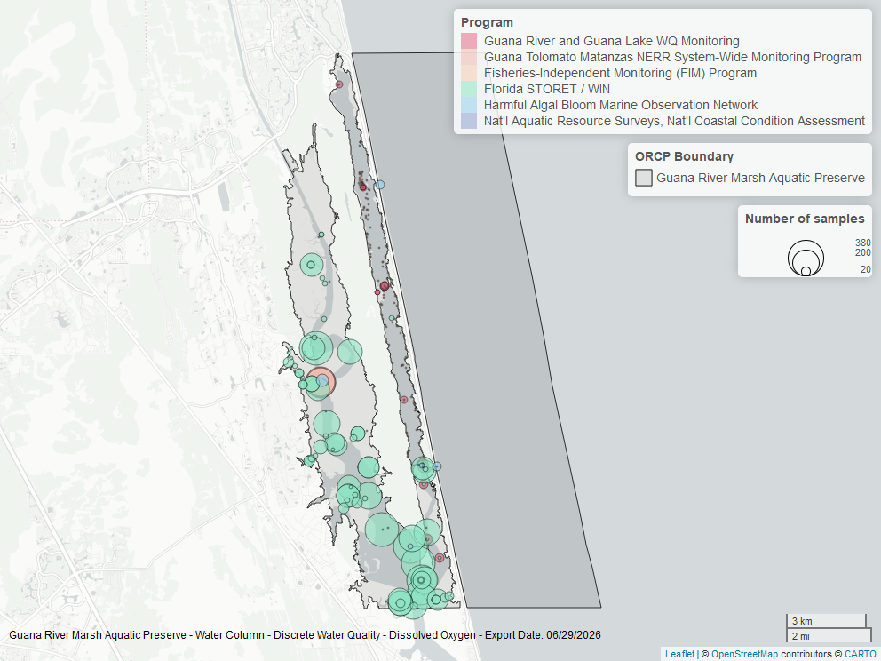

Map showing location of discrete water quality sampling locations within the boundaries of *Guana River Marsh Aquatic Preserve*. The bubble size on the maps above reflect the amount of data available at each sampling site.

### Dissolved Oxygen Saturation - Continuous

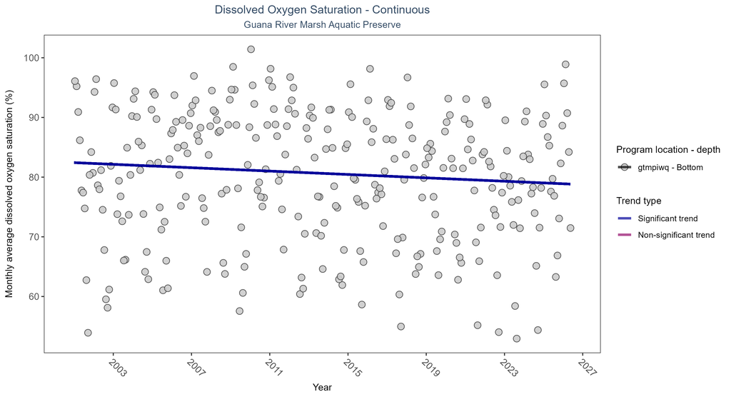

Scatter plot of monthly average dissolved oxygen saturation over time at continuously monitored program locations. Each location is analyzed separately, with significant (blue) or non-significant (magenta) trend lines shown for time series that included five or more years of observations.

Table:

At one program location, monthly average dissolved oxygen saturation decreased by 0.14% per year.

| Program Location | Statistical Trend | Sample Count | Years with Data | Period of Record | Median Result Value | Tau | Sen Intercept | Sen Slope | P |
| --- | --- | --- | --- | --- | --- | --- | --- | --- | --- |
| gtmpiwq | Decreasing trend | 714707 | 26 | 2001 - 2026 | 82.3 | -0.15 | 82.43 | -0.14 | 0 |

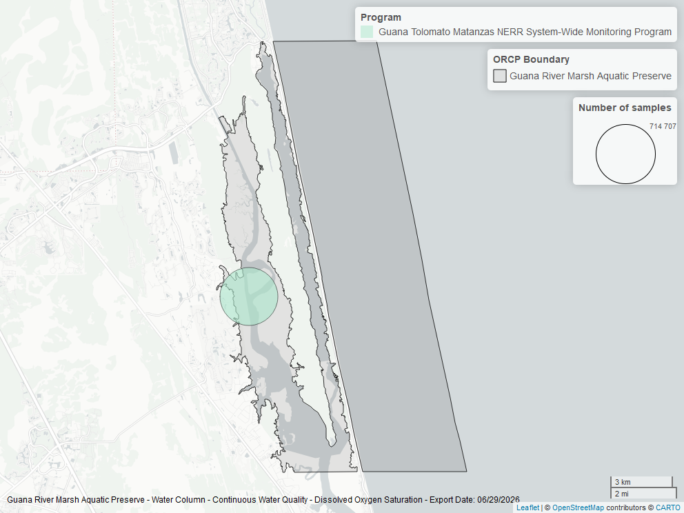

Map showing location of dissolved oxygen saturation continuous water quality sampling locations within the boundaries of *Guana River Marsh Aquatic Preserve*. The bubble size on the maps above reflect the amount of data available at each sampling site.

### Dissolved Oxygen Saturation - Discrete

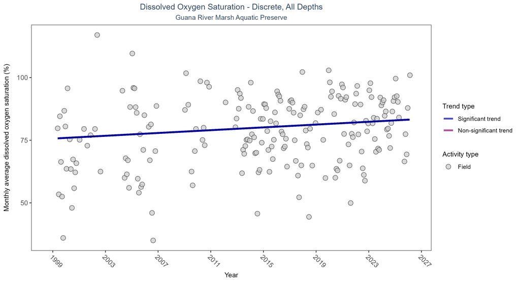

Scatter plot of monthly average dissolved oxygen saturation over time. If the time series included ten or more years of discrete observations, a significant (blue) or non-significant (magenta) trend line is also shown. Only dissolved oxygen saturation values measured in the field (circles) are included in the plot.

Table:

Monthly average dissolved oxygen saturation increased by 0.28% per year.

| Activity Type | Statistical Trend | Sample Count | Years with Data | Period of Record | Median Result Value | Tau | Sen Intercept | Sen Slope | P |
| --- | --- | --- | --- | --- | --- | --- | --- | --- | --- |
| Field | Increasing trend | 1231 | 24 | 1999 - 2026 | 79 | 0.14813 | 75.65186 | 0.27976 | 0.0038 |

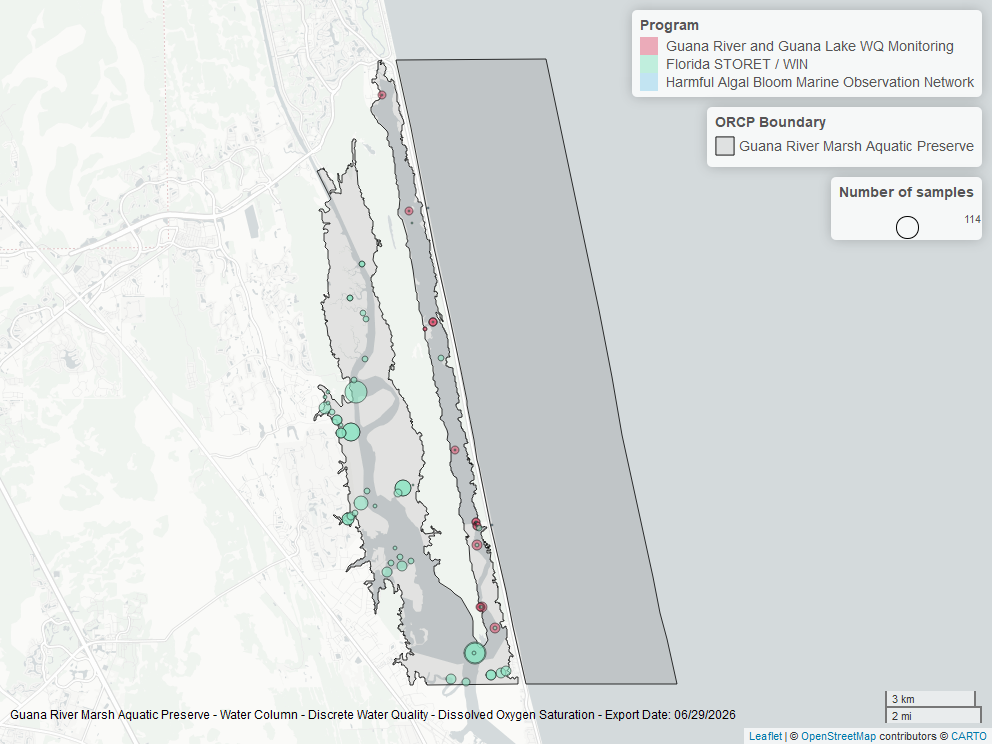

Map showing location of discrete water quality sampling locations within the boundaries of *Guana River Marsh Aquatic Preserve*. The bubble size on the maps above reflect the amount of data available at each sampling site.

### Salinity - Discrete

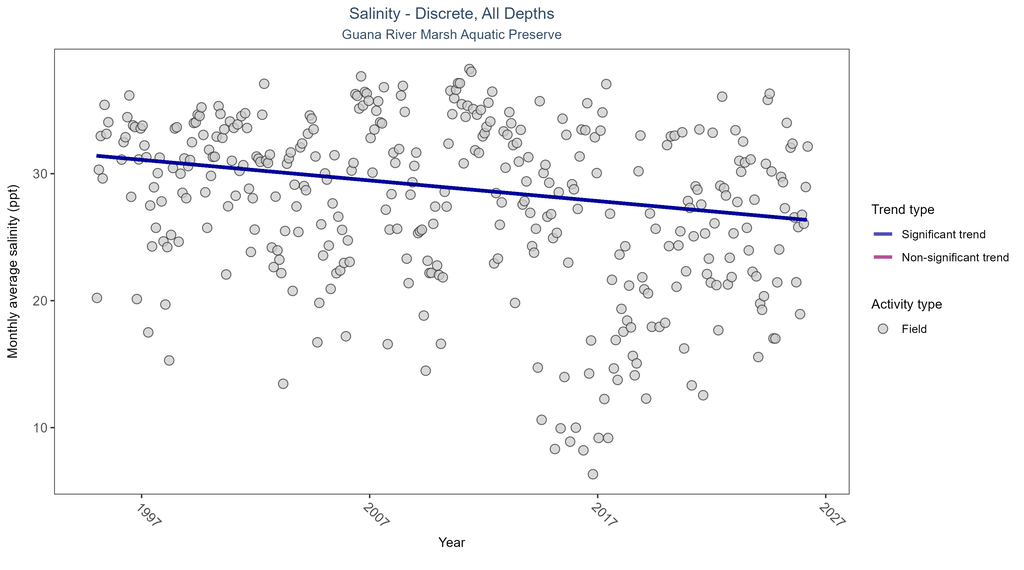

Scatter plot of monthly average salinity over time. If the time series included ten or more years of discrete observations, significant (blue) or non-significant (magenta) trend lines are also shown. Discrete salinity values derived from grab samples analyzed in the field (circles) or the laboratory (triangles) are both included in the plot.

Table:

Monthly average salinity decreased by 0.16 ppt per year.

| Activity Type | Statistical Trend | Sample Count | Years with Data | Period of Record | Median Result Value | Tau | Sen Intercept | Sen Slope | P |
| --- | --- | --- | --- | --- | --- | --- | --- | --- | --- |
| All | Decreasing trend | 8517 | 32 | 1995 - 2026 | 30.9 | -0.18029 | 31.41319 | -0.16222 | 0 |

[figure not shown]

Map showing location of discrete water quality sampling locations within the boundaries of *Guana River Marsh Aquatic Preserve*. The bubble size on the maps above reflect the amount of data available at each sampling site.

### Salinity - Continuous

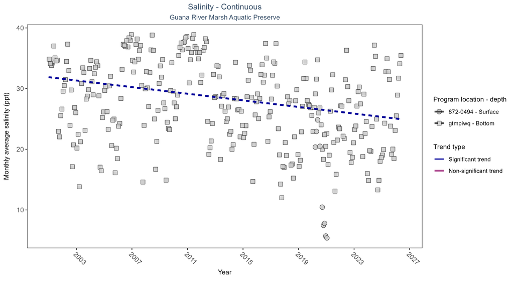

Scatter plot of monthly average salinity over time at continuously monitored program locations. Each location is analyzed separately, with significant (blue) or non-significant (magenta) trend lines shown for time series that included five or more years of observations.

Table:

At one program location, monthly average salinity decreased by 0.27 ppt per year. There was insufficient data to fit a model for one location.

| Program Location | Statistical Trend | Sample Count | Years with Data | Period of Record | Median Result Value | Tau | Sen Intercept | Sen Slope | P |
| --- | --- | --- | --- | --- | --- | --- | --- | --- | --- |
| gtmpiwq | Decreasing trend | 713006 | 26 | 2001 - 2026 | 27.80 | -0.25 | 31.88 | -0.27 | 0 |
| 872-0494 | Insufficient data | 34918 | 2 | 2020 - 2021 | 8.99 | - | - | - | - |

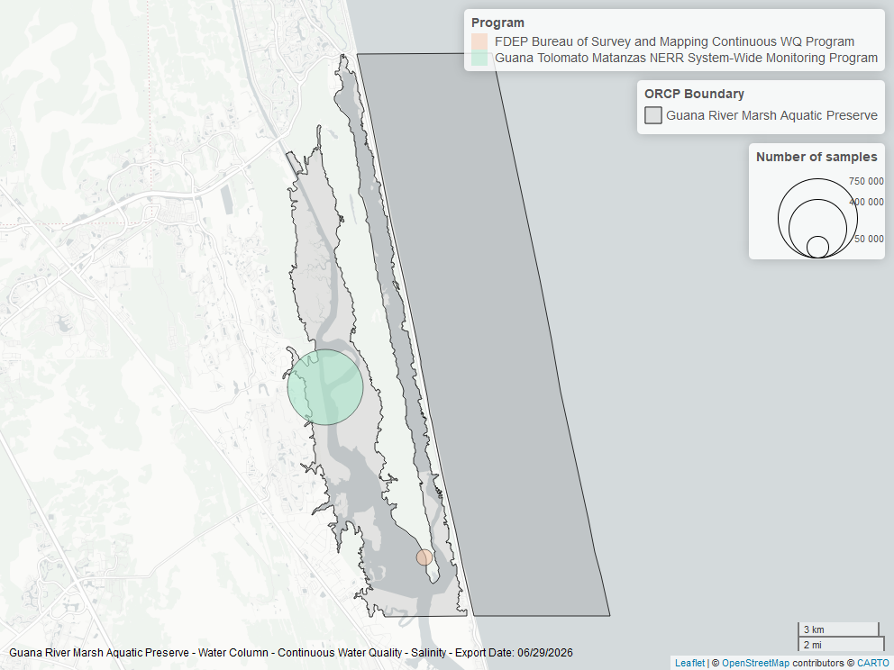

Map showing location of salinity continuous water quality sampling locations within the boundaries of *Guana River Marsh Aquatic Preserve*. The bubble size on the maps above reflect the amount of data available at each sampling site.

### Water Temperature - Continuous

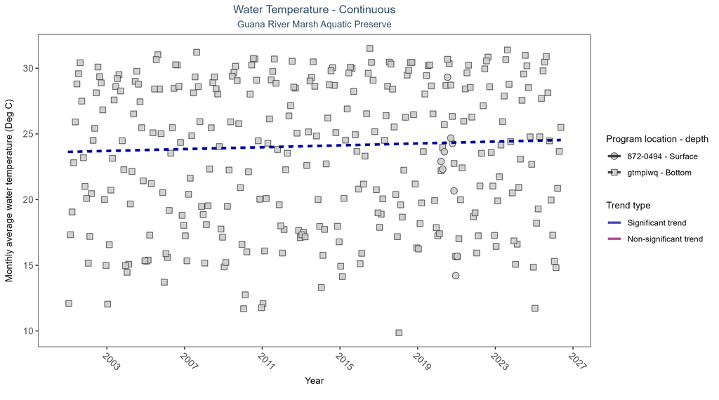

Scatter plot of monthly average water temperature over time at continuously monitored program locations. Each location is analyzed separately, with significant (blue) or non-significant (magenta) trend lines shown for time series that included five or more years of observations.

Table:

At one program location, monthly average water temperature increased by 0.04°C per year. There was insufficient data to fit a model for one location.

| Program Location | Statistical Trend | Sample Count | Years with Data | Period of Record | Median Result Value | Tau | Sen Intercept | Sen Slope | P |
| --- | --- | --- | --- | --- | --- | --- | --- | --- | --- |
| gtmpiwq | Increasing trend | 763299 | 26 | 2001 - 2026 | 24.20 | 0.18 | 23.63 | 0.04 | 0 |
| 872-0494 | Insufficient data | 35473 | 2 | 2020 - 2021 | 22.34 | - | - | - | - |

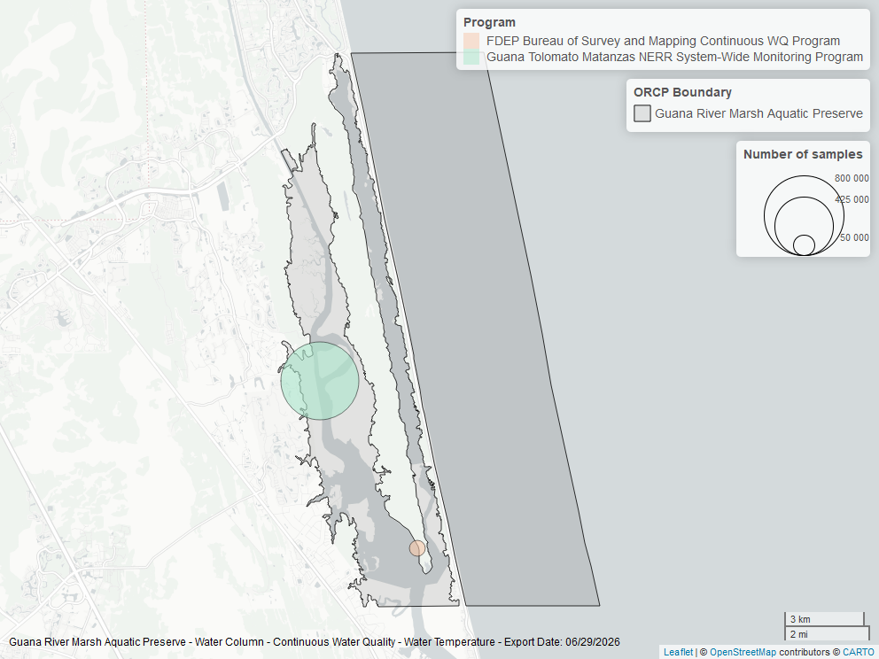

Map showing location of water temperature continuous water quality sampling locations within the boundaries of *Guana River Marsh Aquatic Preserve*. The bubble size on the maps above reflect the amount of data available at each sampling site.

### Water Temperature - Discrete

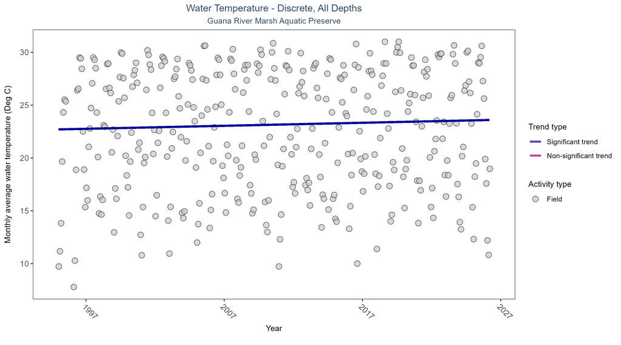

Scatter plot of monthly average water temperature over time. If the time series included ten or more years of discrete observations, a significant (blue) or non-significant (magenta) trend line is also shown. Only water temperature measurements taken in the field (circles) are included in the plot.

Table:

Monthly average water temperature increased by 0.03°C per year.

| Activity Type | Statistical Trend | Sample Count | Years with Data | Period of Record | Median Result Value | Tau | Sen Intercept | Sen Slope | P |
| --- | --- | --- | --- | --- | --- | --- | --- | --- | --- |
| Field | Increasing trend | 8423 | 32 | 1995 - 2026 | 23.1 | 0.10907 | 22.70534 | 0.02856 | 0.0029 |

[figure not shown]

Map showing location of discrete water quality sampling locations within the boundaries of *Guana River Marsh Aquatic Preserve*. The bubble size on the maps above reflect the amount of data available at each sampling site.

### pH - Continuous

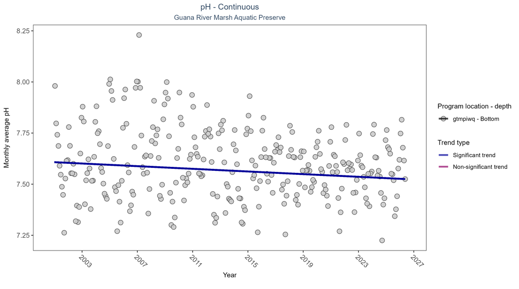

Scatter plot of monthly average pH over time at continuously monitored program locations. Each location is analyzed separately, with significant (blue) or non-significant (magenta) trend lines shown for time series that included five or more years of observations.

Table:

At one program location, monthly average pH decreased by less than 0.01 pH units per year.

| Program Location | Statistical Trend | Sample Count | Years with Data | Period of Record | Median Result Value | Tau | Sen Intercept | Sen Slope | P |
| --- | --- | --- | --- | --- | --- | --- | --- | --- | --- |
| gtmpiwq | Decreasing trend | 705937 | 26 | 2001 - 2026 | 7.6 | -0.17 | 7.61 | 0 | 0 |

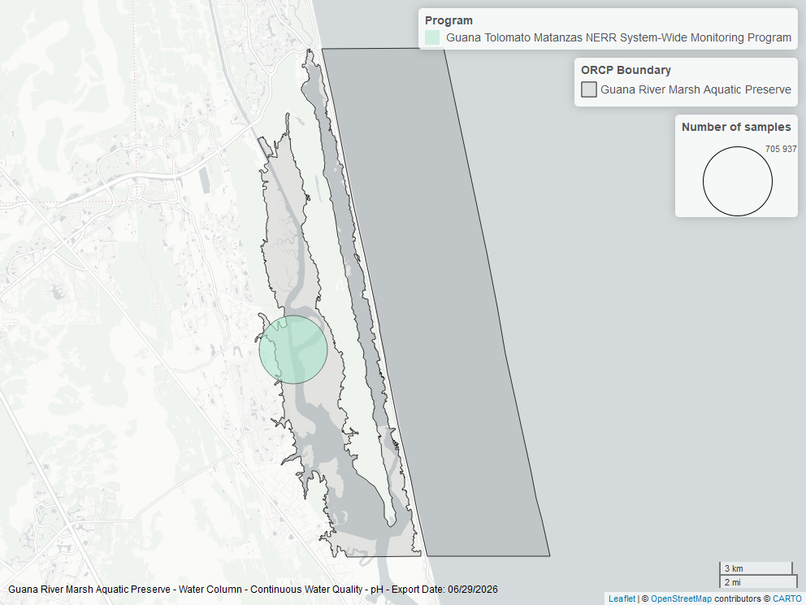

Map showing location of ph continuous water quality sampling locations within the boundaries of *Guana River Marsh Aquatic Preserve*. The bubble size on the maps above reflect the amount of data available at each sampling site.

### pH - Discrete

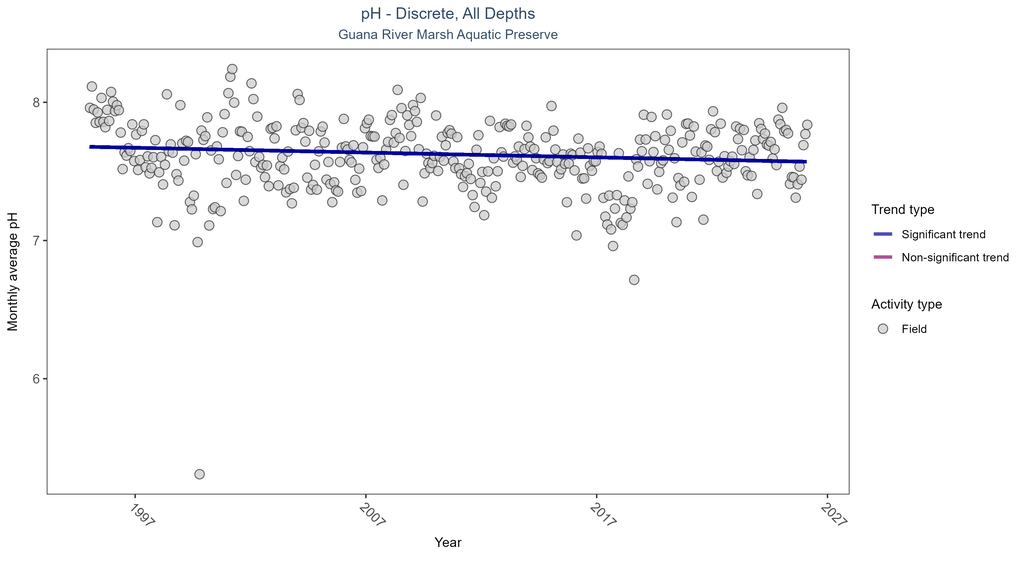

Scatter plot of monthly average pH over time. If the time series included ten or more years of discrete observations, a significant (blue) or non-significant (magenta) trend line is also shown. Only pH values measured in the field (circles) are included in the plot.

Table:

Monthly average pH decreased by less than 0.01 pH units per year.

| Activity Type | Statistical Trend | Sample Count | Years with Data | Period of Record | Median Result Value | Tau | Sen Intercept | Sen Slope | P |
| --- | --- | --- | --- | --- | --- | --- | --- | --- | --- |
| Field | Decreasing trend | 6283 | 32 | 1995 - 2026 | 7.7 | -0.11196 | 7.67802 | -0.00347 | 0.0022 |

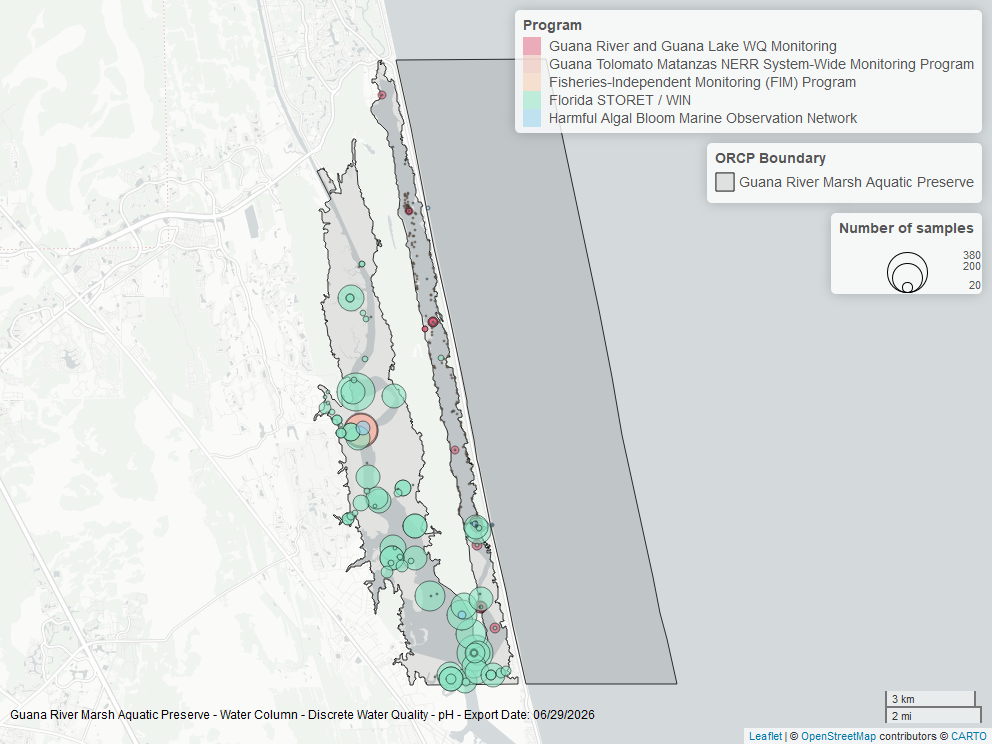

Map showing location of discrete water quality sampling locations within the boundaries of *Guana River Marsh Aquatic Preserve*. The bubble size on the maps above reflect the amount of data available at each sampling site.

### Specific Conductivity - Continuous

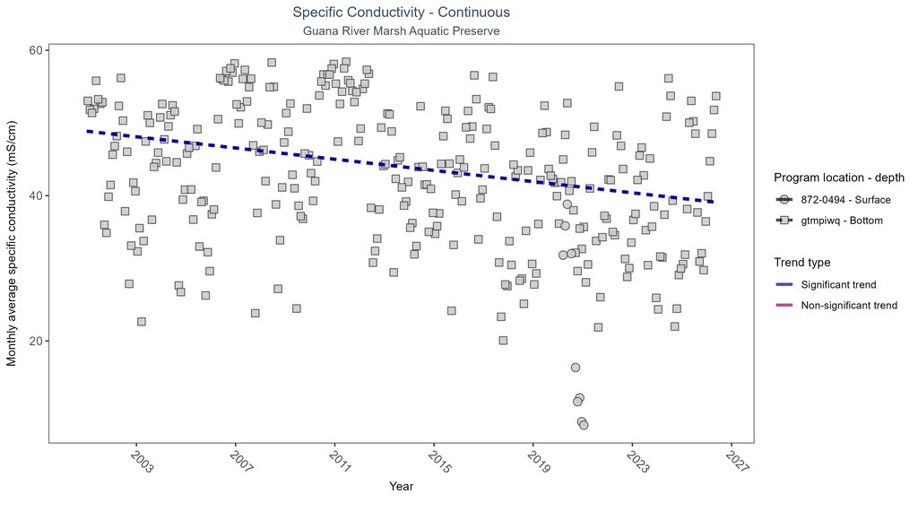

Scatter plot of monthly average specific conductivity over time at continuously monitored program locations. Each location is analyzed separately, with significant (blue) or non-significant (magenta) trend lines shown for time series that included five or more years of observations.

Table:

At one program location, monthly average specific conductivity decreased by 0.39 mS/cm per year. There was insufficient data to fit a model for one location.

| Program Location | Statistical Trend | Sample Count | Years with Data | Period of Record | Median Result Value | Tau | Sen Intercept | Sen Slope | P |
| --- | --- | --- | --- | --- | --- | --- | --- | --- | --- |
| gtmpiwq | Decreasing trend | 713006 | 26 | 2001 - 2026 | 43.23 | -0.25 | 48.87 | -0.39 | 0 |
| 872-0494 | Insufficient data | 34929 | 2 | 2020 - 2021 | 14.00 | - | - | - | - |

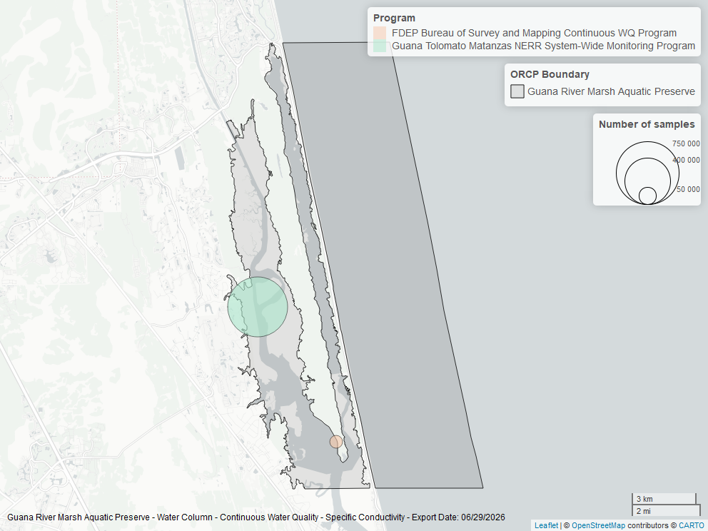

Map showing location of specific conductivity continuous water quality sampling locations within the boundaries of *Guana River Marsh Aquatic Preserve*. The bubble size on the maps above reflect the amount of data available at each sampling site.

## Water Clarity

### Turbidity - Continuous

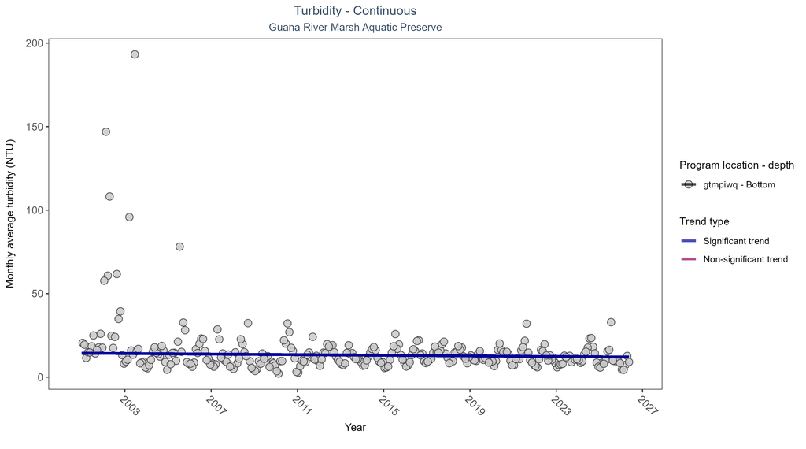

Scatter plot of monthly average turbidity over time at continuously monitored program locations. Each location is analyzed separately, with significant (blue) or non-significant (magenta) trend lines shown for time series that included five or more years of observations.

Table:

At one program location, monthly average turbidity decreased by 0.09 NTU per year.

| Program Location | Statistical Trend | Sample Count | Years with Data | Period of Record | Median Result Value | Tau | Sen Intercept | Sen Slope | P |
| --- | --- | --- | --- | --- | --- | --- | --- | --- | --- |
| gtmpiwq | Decreasing trend | 689004 | 26 | 2001 - 2026 | 10 | -0.13 | 14.35 | -0.09 | 0 |

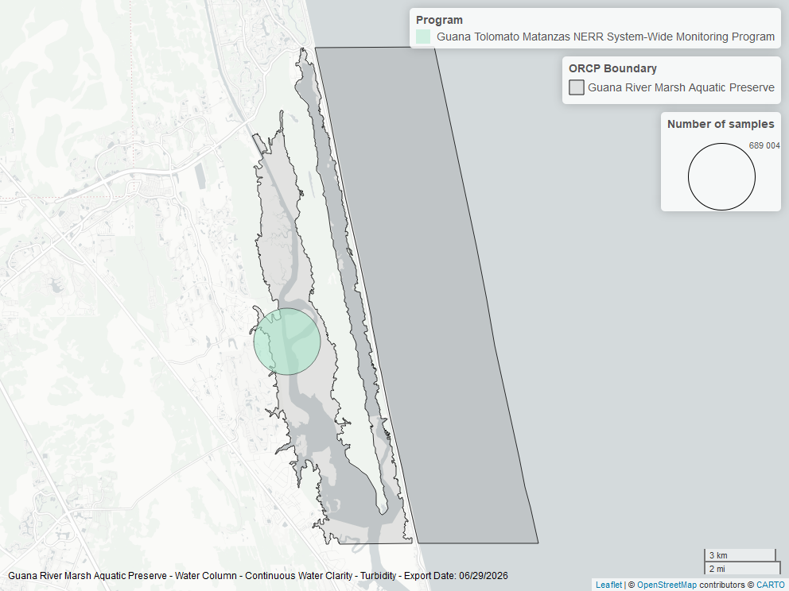

Map showing location of turbidity continuous water quality sampling locations within the boundaries of *Guana River Marsh Aquatic Preserve*. The bubble size on the maps above reflect the amount of data available at each sampling site.

### Turbidity - Discrete

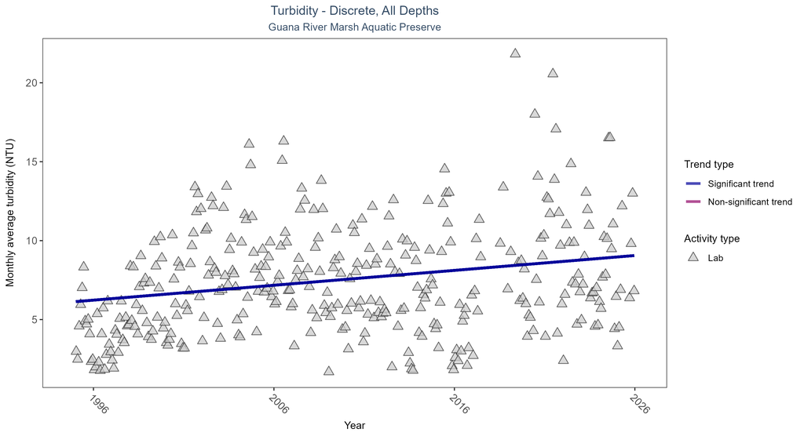

Scatter plot of monthly average turbidity over time. If the time series included ten or more years of discrete observations, a significant (blue) or non-significant (magenta) trend line is also shown. Only turbidity values measured in the laboratory (triangles) are included in the plot.

Table:

Monthly average turbidity increased by 0.09 NTU per year, indicating a decrease in water clarity.

| Activity Type | Statistical Trend | Sample Count | Years with Data | Period of Record | Median Result Value | Tau | Sen Intercept | Sen Slope | P |
| --- | --- | --- | --- | --- | --- | --- | --- | --- | --- |
| Lab | Increasing trend | 5037 | 31 | 1995 - 2025 | 5.2 | 0.21145 | 6.13529 | 0.09426 | 0 |

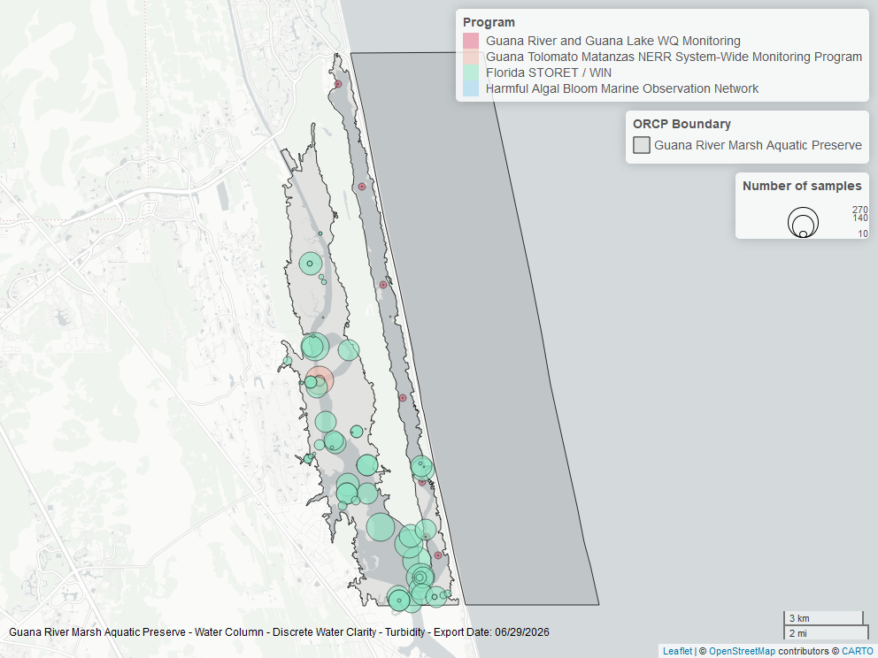

Map showing location of discrete water quality sampling locations within the boundaries of *Guana River Marsh Aquatic Preserve*. The bubble size on the maps above reflect the amount of data available at each sampling site.

### Total Suspended Solids - Discrete

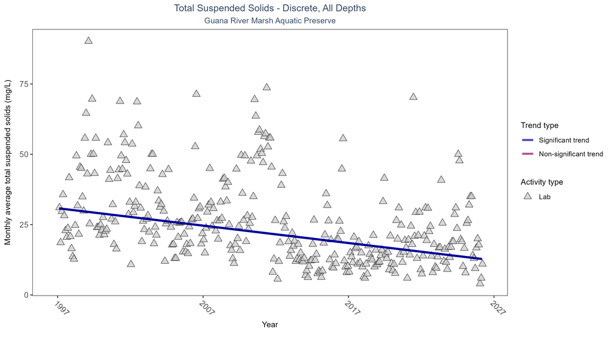

Scatter plot of monthly average total suspended solids (TSS) over time. If the time series included ten or more years of discrete observations, a significant (blue) or non-significant (magenta) trend line is also shown. Only TSS values obtained from laboratory analyses (triangles) are included in the plot.

Table:

Monthly average total suspended solids decreased by 0.62 mg/L per year, indicating an increase in water clarity.

| Activity Type | Statistical Trend | Sample Count | Years with Data | Period of Record | Median Result Value | Tau | Sen Intercept | Sen Slope | P |
| --- | --- | --- | --- | --- | --- | --- | --- | --- | --- |
| Lab | Decreasing trend | 1753 | 30 | 1997 - 2026 | 22 | -0.33847 | 30.82747 | -0.61842 | 0 |

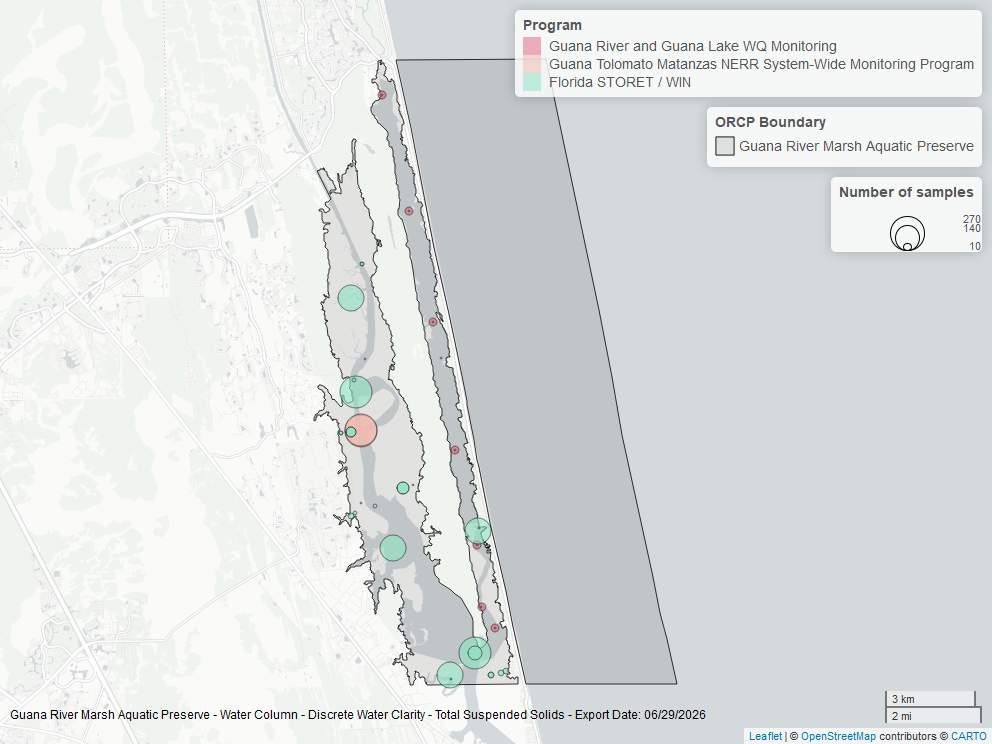

Map showing location of discrete water quality sampling locations within the boundaries of *Guana River Marsh Aquatic Preserve*. The bubble size on the maps above reflect the amount of data available at each sampling site.